# Stat 480 - Homework #5 - Practice

Your Name

2/15/2018

## Flying etiquette

1. Download the RMarkdown file with these homework instructions to use as a template for your work. Make sure to replace “Your Name” in the YAML with your name.
2. FiveThirtyEight is a website founded by Statistician and writer Nate Silver to publish results from opinion poll analysis, politics, economics, and sports blogging. One of the featured articles considers [flying etiquette](https://fivethirtyeight.com/features/airplane-etiquette-recline-seat/). This article is based on data collected by FiveThirtyEight and publicly available on github. Use the code below to read in the data from the survey:

```r
fly <- read.csv("https://raw.githubusercontent.com/fivethirtyeight/data/master/flying-etiquette-survey/flying-etiquette.csv")
```

3. Some people do not travel often by plane. Provide a breakdown of travel frequency (use variable `How.often.do.you.travel.by.plane.`). Exclude non-fliers from any future analysis. How many responses are we still considering?

```r
summary(fly$How.often.do.you.travel.by.plane.)
```

```
## A few times per month  A few times per week             Every day
##                    29                     4                     3
##                 Never  Once a month or less   Once a year or less
##                   166                   205                   633
```

```r
fly <- dplyr::filter(fly, How.often.do.you.travel.by.plane. != "Never")
nrow(fly)
```

```
## [1] 874
```

4. Demographic variables `Education`, `Gender`, `Household.Income` and `Age` were collected for each participant of the survey. Draw a barchart for each one of these variables (for a total of four barcharts) and interpret the result. Make sure that the levels are ordered “sensibly”.

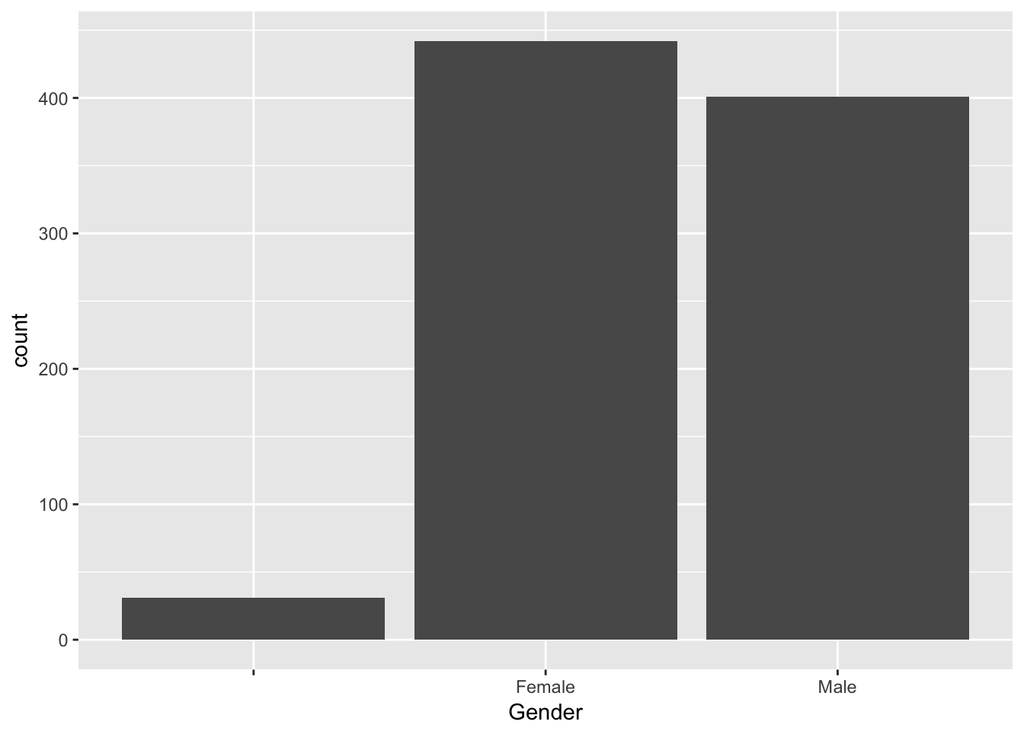

```r
#levels(fly$Age)
fly$Age <- factor(fly$Age, levels=c("18-29", "30-44", "45-60", "> 60", ""))
fly$Household.Income <- factor(fly$Household.Income, levels = c("$0 - $24,999","$25,000 - $49,999", "$50,000 - $99,999", "$100,000 - $149,999", "150000", ""))
fly$Education <- factor(fly$Education, levels = c("Less than high school degree", "High school degree", "Some college or Associate degree", "Bachelor degree",  "Graduate degree", ""))


library(ggplot2)
ggplot(data = fly, aes(x = Gender)) + geom_bar()
```

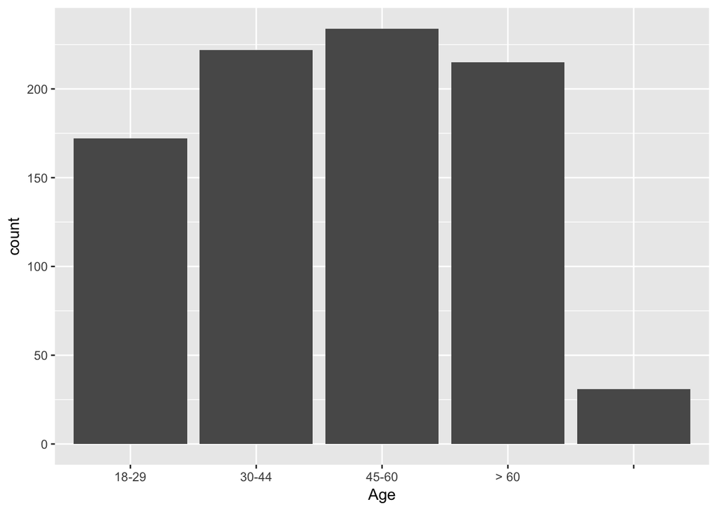

```r
ggplot(data = fly, aes(x = Age)) + geom_bar()
```

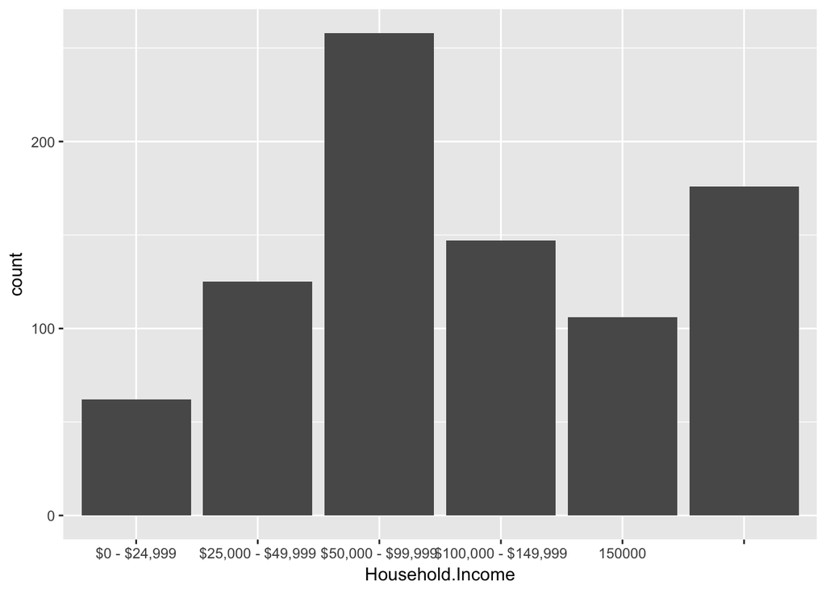

```r
ggplot(data = fly, aes(x = Household.Income)) + geom_bar()
```

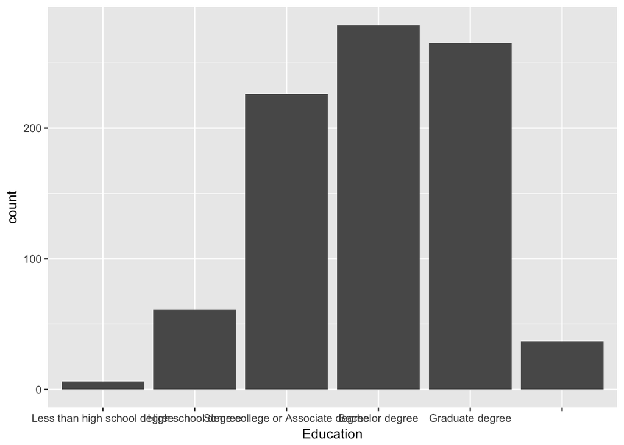

```r
ggplot(data = fly, aes(x = Education)) + geom_bar()
```

5. Run the command below and interpret the output. What potential purpose can you see for the chart?

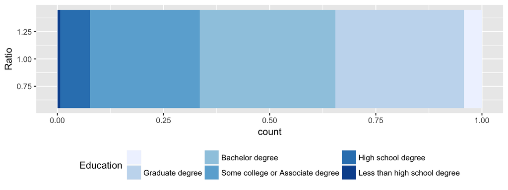

```r
fly$Education = with(fly, factor(Education, levels = rev(levels(Education))))

ggplot(data = fly, aes(x = 1)) +
  geom_bar(aes(fill=Education), position="fill") +
  coord_flip() +
  theme(legend.position="bottom") +
  scale_fill_brewer() +
  xlab("Ratio")
```

6. Rename the variable `On.a.6.hour.flight.from.NYC.to.LA..how.many.times.is.it.acceptable.to.get.up.if.you.re.not.in.an.aisle.seat` to `get.up`. How many levels does the variable `get.up` have, and what are these levels? Rename the level labeled “” to “Not answered”. Bring the levels of `get.up` in an order that reflects the number of times people find it OK to get up from smallest to largest. Put the level “Not answered” last. Draw a barchart of variable `get.up`. Interpret the result. Incorporate gender in the plot such that you can compare/find differences in responses between men and women.

```r
names(fly)[11] <- "get.up"
levels(fly$get.up)
```

```
## [1] ""
## [2] "Four times"
## [3] "It is not okay to get up during flight"
## [4] "More than five times times"
## [5] "Once"
## [6] "Three times"
## [7] "Twice"
```

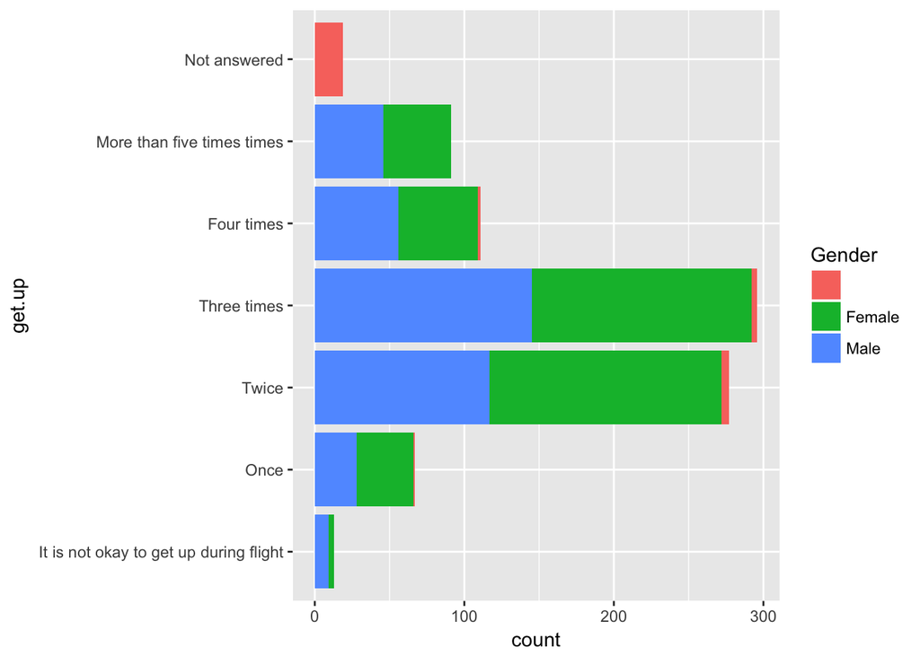

```r
levels(fly$get.up)[1] <- "Not answered"
fly$get.up <- factor(fly$get.up,
       levels= c("It is not okay to get up during flight",
                 "Once",
                "Twice",
                "Three times",
                "Four times",
                "More than five times times",
                "Not answered"))
library(ggplot2)
ggplot(fly, aes(x = get.up)) + geom_bar(aes(fill=Gender)) + coord_flip()
```

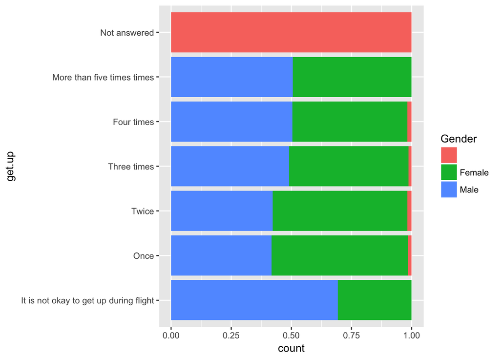

```r
ggplot(fly, aes(x = get.up)) + geom_bar(aes(fill=Gender), position="fill") + coord_flip()
```

Due date: the homework is due before class on Thursday.

For the submission: submit your solution in an R Markdown file and (just for insurance) submit the corresponding html file with it.